# HW 2 Solution

Penelope Pooler

Due 1/31/2024

```r
# this line specifies options for default options for all R Chunks
knitr::opts_chunk$set(echo=T, highlight=T)

# suppress scientific notation
options(scipen=100)

# install helper package (pacman) if needed
if (!require("pacman")) install.packages("pacman", repos = "http://lib.stat.cmu.edu/R/CRAN/")
# install and load required packages
# pacman should be first package in parentheses and then list others
pacman::p_load(pacman, tidyverse, gridExtra, magrittr)

# verify packages (comment out in finished documents)
p_loaded()
```

```
##  [1] "magrittr"  "gridExtra" "lubridate" "forcats"   "stringr"   "dplyr"
##  [7] "purrr"     "readr"     "tidyr"     "tibble"    "ggplot2"   "tidyverse"
## [13] "pacman"
```

### HW 2 - Part 1: **`glimpse`** and **`unique`**

#### Chunk 2: Examining the **`diamonds`** Data

- This chunk reviews the **`glimpse`** and **`unique`** commands from Week 1
- You are encouraged to add your own notes here and/or your own comments in the chunk below so that you understand the code and what it does.

```r
# save the diamonds dataset to your Global Environment
my_diamonds <- diamonds

# show data summary
# without piping
glimpse(my_diamonds)
```

```
## Rows: 53,940
## Columns: 10
## $ carat   <dbl> 0.23, 0.21, 0.23, 0.29, 0.31, 0.24, 0.24, 0.26, 0.22, 0.23, 0.…
## $ cut     <ord> Ideal, Premium, Good, Premium, Good, Very Good, Very Good, Ver…
## $ color   <ord> E, E, E, I, J, J, I, H, E, H, J, J, F, J, E, E, I, J, J, J, I,…
## $ clarity <ord> SI2, SI1, VS1, VS2, SI2, VVS2, VVS1, SI1, VS2, VS1, SI1, VS1, …
## $ depth   <dbl> 61.5, 59.8, 56.9, 62.4, 63.3, 62.8, 62.3, 61.9, 65.1, 59.4, 64…
## $ table   <dbl> 55, 61, 65, 58, 58, 57, 57, 55, 61, 61, 55, 56, 61, 54, 62, 58…
## $ price   <int> 326, 326, 327, 334, 335, 336, 336, 337, 337, 338, 339, 340, 34…
## $ x       <dbl> 3.95, 3.89, 4.05, 4.20, 4.34, 3.94, 3.95, 4.07, 3.87, 4.00, 4.…
## $ y       <dbl> 3.98, 3.84, 4.07, 4.23, 4.35, 3.96, 3.98, 4.11, 3.78, 4.05, 4.…
## $ z       <dbl> 2.43, 2.31, 2.31, 2.63, 2.75, 2.48, 2.47, 2.53, 2.49, 2.39, 2.…
```

```r
# with piping
my_diamonds |>
  glimpse(width = 50)
```

```
## Rows: 53,940
## Columns: 10
## $ carat   <dbl> 0.23, 0.21, 0.23, 0.29, 0.31, 0.…
## $ cut     <ord> Ideal, Premium, Good, Premium, G…
## $ color   <ord> E, E, E, I, J, J, I, H, E, H, J,…
## $ clarity <ord> SI2, SI1, VS1, VS2, SI2, VVS2, V…
## $ depth   <dbl> 61.5, 59.8, 56.9, 62.4, 63.3, 62…
## $ table   <dbl> 55, 61, 65, 58, 58, 57, 57, 55, …
## $ price   <int> 326, 326, 327, 334, 335, 336, 33…
## $ x       <dbl> 3.95, 3.89, 4.05, 4.20, 4.34, 3.…
## $ y       <dbl> 3.98, 3.84, 4.07, 4.23, 4.35, 3.…
## $ z       <dbl> 2.43, 2.31, 2.31, 2.63, 2.75, 2.…
```

```r
# examine ordinal variables using unique
# without piping
unique(my_diamonds$cut)
```

```
## [1] Ideal     Premium   Good      Very Good Fair
## Levels: Fair < Good < Very Good < Premium < Ideal
```

```r
# with piping
# pull command selects a single variable from a dataset
my_diamonds |> pull(cut) |> unique()
```

```
## [1] Ideal     Premium   Good      Very Good Fair
## Levels: Fair < Good < Very Good < Premium < Ideal
```

```r
# choose one of these methods to examine:

# ordered levels of clarity
my_diamonds |> pull(clarity) |> unique()
```

```
## [1] SI2  SI1  VS1  VS2  VVS2 VVS1 I1   IF
## Levels: I1 < SI2 < SI1 < VS2 < VS1 < VVS2 < VVS1 < IF
```

```r
# ordered levels of color
unique(my_diamonds$color)
```

```
## [1] E I J H F G D
## Levels: D < E < F < G < H < I < J
```

### HW2 - Part 2: **`select`**

#### Chunk 3: Selecting variables in a dataset

- This chunk demonstrates using the **`select`** command to select variables.
- You are encouraged to add your own notes here and/or your own comments in the chunk below so that you understand the code and what it does.

```r
# creates a new dataset, my_diamonds1
# selects variables we want to keep
# select can also re-order variables (price is now first)
my_diamonds1 <- my_diamonds |>
  select(price, carat, cut, color, clarity, depth, table)

# same command, but shorter
# used : to specify consecutive variables
my_diamonds1 <- my_diamonds |>
  select(price, carat:table)

# creates a new dataset, my_diamonds2
# identical to above but we use ! to exclude variables
my_diamonds2 <- my_diamonds |>
  select(!c(x,y,z))

# create my_diamonds3 using select to keep these variables only:
# price, carat, color, cut, clarity

my_diamonds3 <- my_diamonds |>
  select(price, carat, cut, color, clarity)

# create my_diamonds4 using select to EXCLUDE these variables
# depth, table, x, y, z

my_diamonds4 <- my_diamonds |>
  select(!c(x,y,z, depth, table))
```

### HW2 - Part 3: **`slice`**

#### Chunk 4: Selecting rows by row number

- This chunk demonstrates using the **`slice`** command to select rows.
- You are encouraged to add your own notes here and/or your own comments in the chunk below so that you understand the code and what it does.

```r
my_diamonds1 <- my_diamonds |>
  select(price, carat, cut, color, clarity, depth, table) |>
  slice(5001:35000)

my_diamonds2 <- my_diamonds |>
  select(price, carat:table) |>
  slice(1, 200, 2301:3000, 29000:32000)

# Use the code from Chunk 3  that you wrote to create my_diamonds3
# add on to that code to limit my_diamonds3 to rows:
# 1001 through 30000 and 45001 through 50000

my_diamonds3 <- my_diamonds |>
  select(price, carat, cut, color, clarity) |>
  slice(1001:30000, 45001:50000)
```

### HW 2 - Part 4: **`filter`** and **`summary`**

#### Chunk 5: Filtering data by value and summarizing

- This chunk demonstrates using the **`filter`** command to select rows by variables values and using **`summary`**
- You are encouraged to add your own notes here and/or your own comments in the chunk below so that you understand the code and what it does.

```r
# filtering my_diamonds1 to
# carat weight greater than or equal to 2 (carat >=2)
# cut is Premium or Ideal (cut %in% c("Premium", "Ideal"))
my_diamonds1 <- my_diamonds |>
  select(price, carat:table) |>
  slice(5001:35000) |>
  filter(carat >= 2) |>
  filter(cut %in% c("Premium", "Ideal"))

# same filtering tasks as above
# !cut used to exclude cuts Fair, Good, Very Good
my_diamonds1 <- my_diamonds |>
  select(price, carat:table) |>
  slice(5001:35000) |>
  filter(carat >= 2) |>
  filter(!cut %in% c("Fair", "Good", "Very Good"))

# same filtering tasks as above
# both filtering tasks combined using and operator &
my_diamonds1 <- my_diamonds |>
  select(price, carat:table) |>
  slice(5001:35000) |>
  filter(carat >= 2 & cut %in% c("Premium", "Ideal"))

# summary of color in my_diamonds1
summary(my_diamonds1$color)
```

```
##   D   E   F   G   H   I   J
##  28  53  83 171 334 390 273
```

```r
# same summary with piping
my_diamonds1 |> pull(color) |> summary()
```

```
##   D   E   F   G   H   I   J
##  28  53  83 171 334 390 273
```

```r
# Use any one of the examples above to filter my_diamonds3 to:
# carat weight greater than or equal to 1.25
# cut is Very Good, Premium, or Ideal

my_diamonds3 <- my_diamonds |>
  select(price, carat, cut, color, clarity) |>
  slice(1001:30000, 45001:50000) |>
  filter(carat >= 1.25) |>
  filter(cut %in% c("Very Good", "Premium", "Ideal"))


# summarize clarity in the my_diamonds3 dataset (number of obs. in each level)
# use the summary command, with or without piping
# above I show how I summarized the color variable

my_diamonds3 |> pull(clarity) |> summary()
```

```
##   I1  SI2  SI1  VS2  VS1 VVS2 VVS1   IF
##  142 1987 1715 1520  928  294  122   65
```

### HW 2 - Part 5: Creating plots with **`ggplot`**

#### Creating Basic Plots

- In Part 5, you will create a chunk (Ctrl/Cmd + Alt + i) and copy the R code for Part 5 from **HW2_Instructions.html** into the chunk you create.
- The provided R code demonstrates using
  - **`ggplot`** to make some basic plots
  - **`grid.arrange`** to present multiple plots in a grid or column.
- You are encouraged to add your own notes here and/or your own comments in the chunk you create so that you understand the code and what it does.

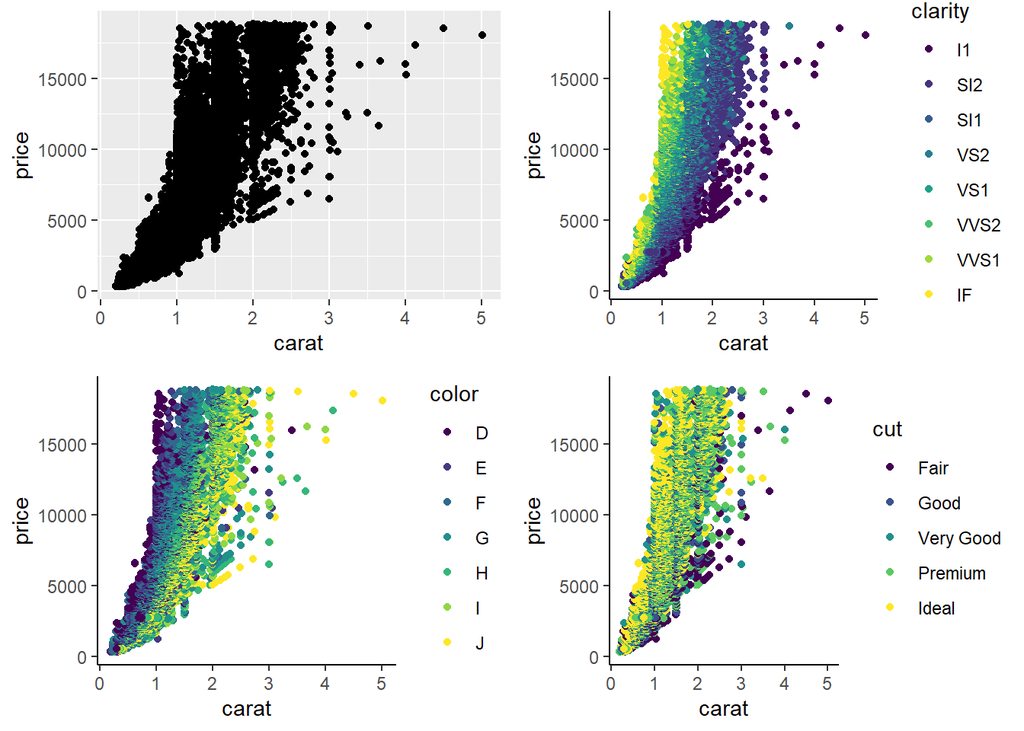

```r
#### scatter plots ####

# scatter_none is the most basic scatter plot of carat vs. price
# no other variables are included
# to view this plot by itself (not required), enclose code in parentheses
scatter_none <- my_diamonds |>
   ggplot() +
   geom_point(aes(x=carat, y=price))


# scatter_clarity adds the option color=clarity to the aes (aesthetic)
# observations are color coded by diamond clarity level
# theme_classic() added to remove background

scatter_clarity <- my_diamonds |>
  ggplot() +
  geom_point(aes(x=carat, y=price, color=clarity)) +
  theme_classic()


# create plot named scatter_cut using the above code
# change color=clarity to color=cut

scatter_cut <- my_diamonds |>
  ggplot() +
  geom_point(aes(x=carat, y=price, color=cut)) +
  theme_classic()


# create plot named scatter_color using the above code
# change color=clarity to color=color

scatter_color <-  my_diamonds |>
  ggplot() +
  geom_point(aes(x=carat, y=price, color=color)) +
  theme_classic()



# plot all 4 plots above in a 2x2 grid and answer Blackboard Questions

grid.arrange(scatter_none, scatter_clarity,
              scatter_color, scatter_cut, ncol=2)
```

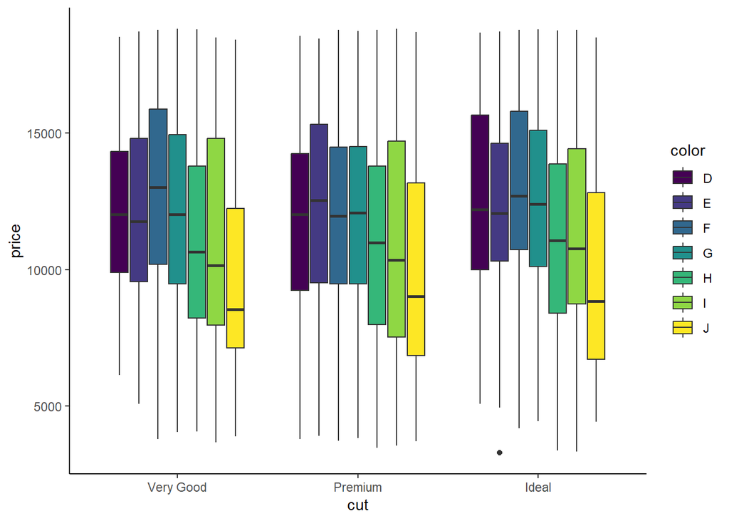

```r
#### boxplots ####

# below is a plot of grouped side-by_side boxplots
# Within each cut category there is a separate boxplot for each color
# this is one good way to examine categorical data

# code is enclosed in parentheses
# plot is saved as box_color AND is shown on the screen

(box_color <- my_diamonds3 |>
  ggplot() +
  geom_boxplot(aes(x=cut, y=price, fill=color))+
  theme_classic())
```

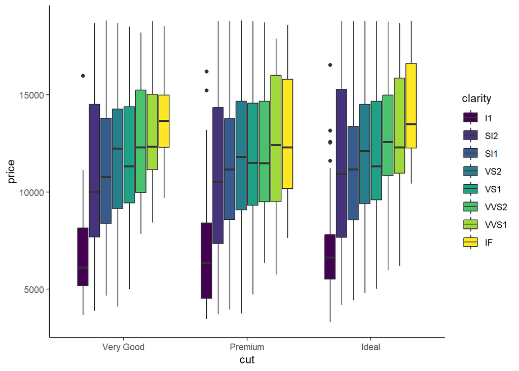

```r
# create a plot of grouped side-by_side boxplots that show
# boxplots for each clarity category with each cut category

# same plot as above but change fill=color to fill=clarity
# name this plot box_clarity

(box_clarity <- my_diamonds3 |>
  ggplot() +
  geom_boxplot(aes(x=cut, y=price, fill=clarity))+
  theme_classic())
```

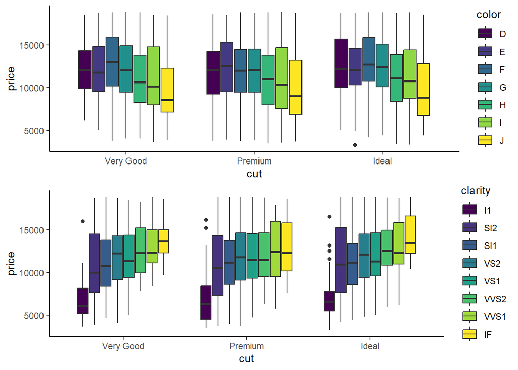

```r
# plot these two sets of plots in a stacked column (ncol=1)

grid.arrange(box_color, box_clarity, ncol=1)
```